# USIALE 2018 Tweets

Jeff Hollister (borrowed from François Michonneau)

[output not shown]

## About this document

This document was generated using RMarkdown, and the source is available on GitHub at: https://github.com/fmichonneau/evol2017-tweets.

Pull requests to add other figures or fix bugs are welcome.

This document (and associated code) is released under a CC0 licence.

If you have questions or comments, I am on twitter at fmic_ or by email at francois.michonneau@gmail.com

## The 5 most favorited tweets

> Dinner at #usiale2018 with past and present #TurnerLab members. Thankful for such good colleagues! @carlyziter @tylerhoecker @RoseGrvs @EricaSmithwick @GergelSarah @WiscEcology https://t.co/cPOXiL8YCz

> — MonicaGTurner | [2018-04-10](https://twitter.com/MonicaGTurner/status/983539608549056512) | 0 retweets, 39 favorites.

> Heads up to those who are seeing #usiale2018 come across their timelines and don’t know what it is! It’s the annual meeting for the US Chapter of the Intl Assoc of Landscape Ecologists. That’s a mouthful, I know! But it’s a great meeting/group of scientists. My fave meeting.

> — gigi_rose | [2018-04-08](https://twitter.com/gigi_rose/status/983073309045743617) | 8 retweets, 30 favorites.

> My poster about the controls of fire activity over centennial time scales is up at #usiale2018 - stop by! https://t.co/KIU3CkvlPJ

> — tylerhoecker | [2018-04-09](https://twitter.com/tylerhoecker/status/983446787305467904) | 4 retweets, 19 favorites.

> Slides from my #usiale2018 talk about Pattern-Based Spatial Analysis are available at https://t.co/YPsVQwdCRP. #sil https://t.co/HS6httGSCk

> — jakub_nowosad | [2018-04-10](https://twitter.com/jakub_nowosad/status/983501116779483136) | 1 retweets, 18 favorites.

> On deck for this week - prepping my #usiale2018 talk. *Really* excited for this one. It’s basically got it all: Trees! Cities! GIS! GAMs! Bicycles!

> — carlyziter | [2018-04-02](https://twitter.com/carlyziter/status/980848631120056322) | 3 retweets, 16 favorites.

> Big shout-out to all the landscape ecology students that made #usiale2018 such a fantastic conference! Remember if you’d like to be a grad student rep, check your email for further instructions and submit your information by 5pm today! @us_iale

> — erinbuchholtz | [2018-04-13](https://twitter.com/erinbuchholtz/status/984875451045773312) | 5 retweets, 16 favorites.

> May have tried to squeeze too much into my 12 minutes, but was great sharing collaborative #socialecologicalsystem research on people and elephants (with @laurenredmore) at #usiale2018! @us_iale @abstamu @Ecoexist https://t.co/uufgtWgmIv

> — erinbuchholtz | [2018-04-09](https://twitter.com/erinbuchholtz/status/983467241357312001) | 2 retweets, 16 favorites.

> “Landscape ecologists study what you can see from an airplane window. Fields over Quebec. Long linear pattern a legacy of the French seigneurial system. @us_iale #usiale2018 https://t.co/hFkwAilPt8

> — YolandaWiersma | [2018-04-08](https://twitter.com/YolandaWiersma/status/982945758461747200) | 0 retweets, 16 favorites.

## The 5 most retweeted tweets

> Official @us_iale conference Social Media policy is: (same as @ESA_org ) -please no photos of speaker or slides unless they give express permission -you may send text based posts about a talk UNLESS speaker has asked not to and/or put a no-tweet logo on their slides #usiale2018

> — us_iale | [2018-04-06](https://twitter.com/us_iale/status/982385859004682240) | 11 retweets, 9 favorites.

> Recommended read: GPS tracking of 57 spp shows it’s hard to get around. Animals move much less in landscapes with high human footprint. Learned about this (and more!) while at #usiale2018. https://t.co/bn5Zr3SMrZ

> — MonicaGTurner | [2018-04-12](https://twitter.com/MonicaGTurner/status/984460950081359872) | 8 retweets, 10 favorites.

> Heads up to those who are seeing #usiale2018 come across their timelines and don’t know what it is! It’s the annual meeting for the US Chapter of the Intl Assoc of Landscape Ecologists. That’s a mouthful, I know! But it’s a great meeting/group of scientists. My fave meeting.

> — gigi_rose | [2018-04-08](https://twitter.com/gigi_rose/status/983073309045743617) | 8 retweets, 30 favorites.

> Going to #usiale2018? Working on socio-environmental systems #CHANS and sustainable development goals #SDGs ? Our workshop (W2) Tue. 1-5 PM will teach you the brand new #telecoupling-geoapp https://t.co/24hhECRTqh @Suegnic @AnnaHerzberger @dillott @geocanuck help RT!

> — f_tonini | [2018-04-07](https://twitter.com/f_tonini/status/982677441930985472) | 7 retweets, 7 favorites.

> Lots of great conferences happening this week! Check out #AOS18AZ #usiale2018 #AAG2018 for urban ecology and much more! https://t.co/vFpaIlPWLH

> — JUrbanEcology | [2018-04-12](https://twitter.com/JUrbanEcology/status/984261845254135809) | 6 retweets, 7 favorites.

## Top tweeters

All generated tweets (including retweets)

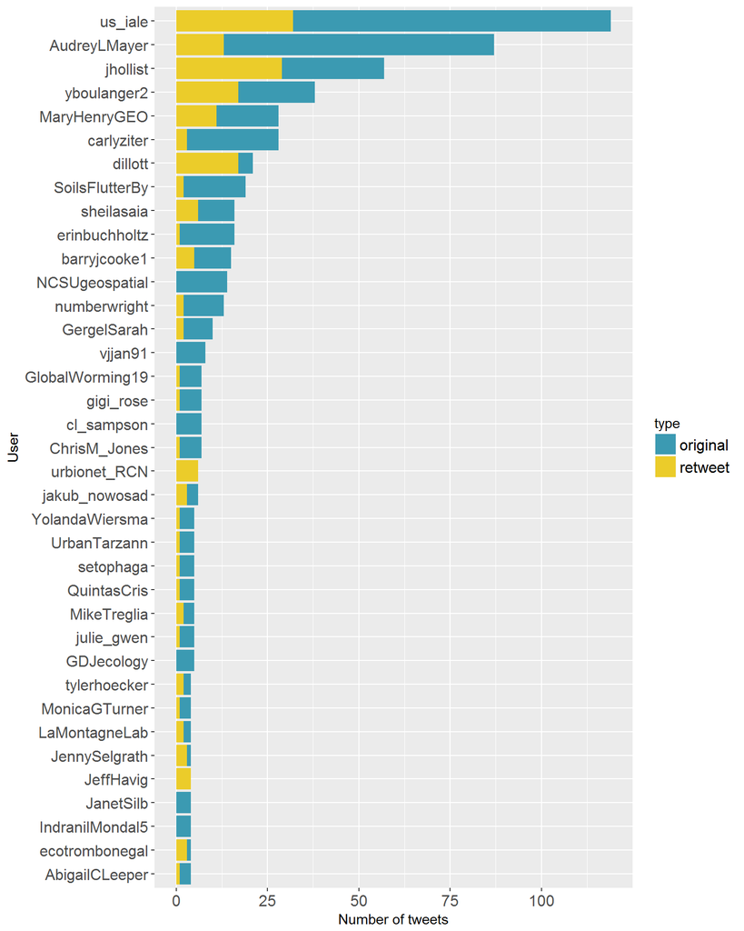

Only for original tweets (retweets excluded)

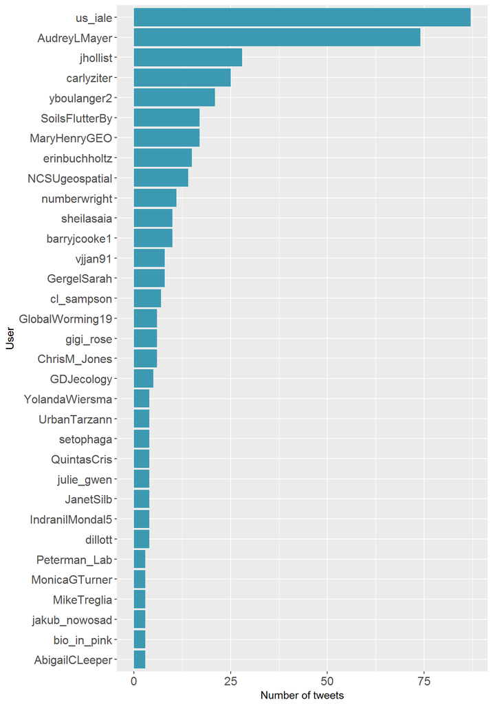

## Most favorited/retweeted users

The figures below only include users who tweeted 5+ times, and don’t include retweets.

### Number of favorites received by users

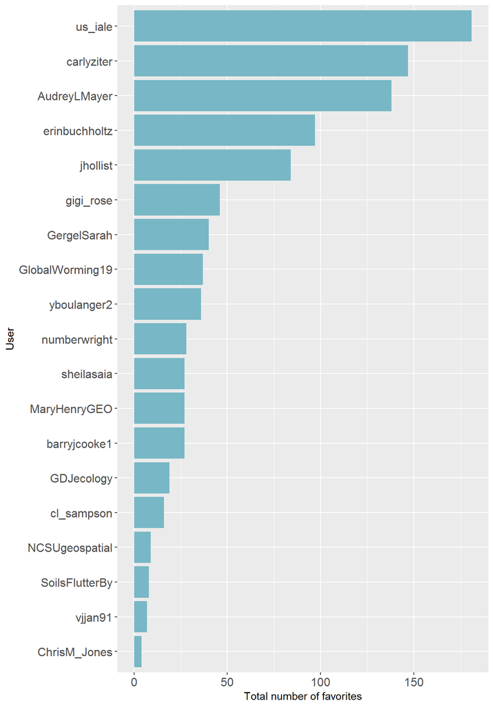

### Number of retweets received by users

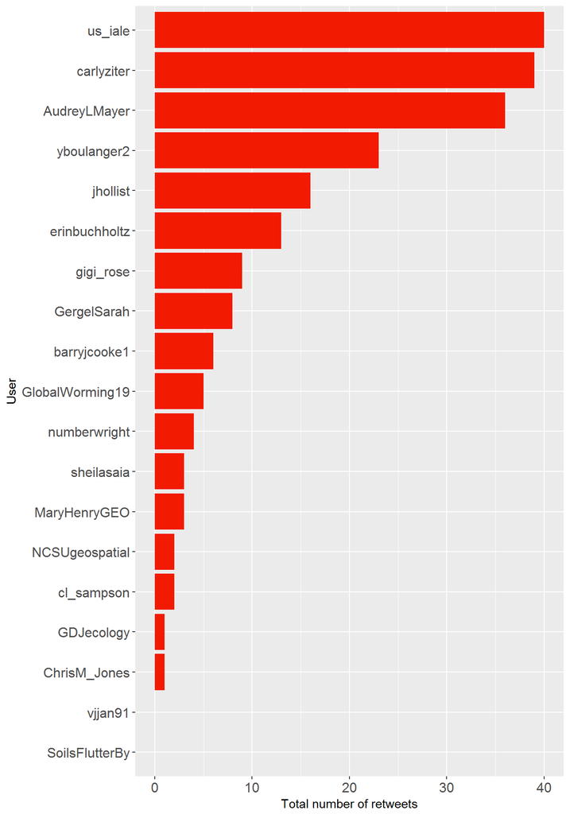

### Mean numbers of favorites received

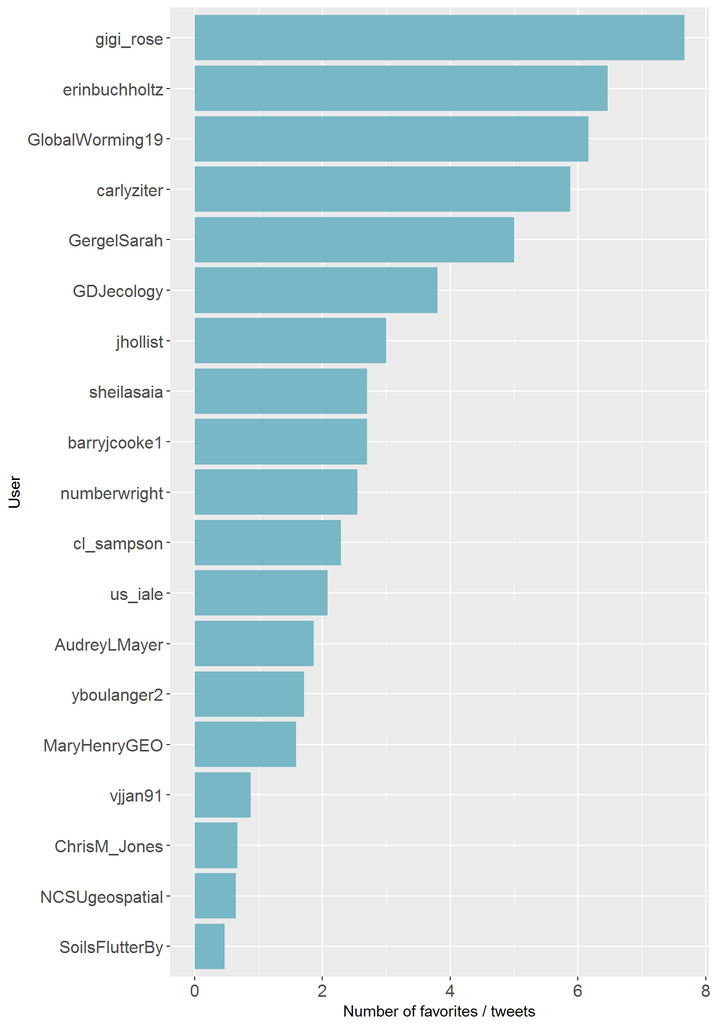

### Mean numbers of retweets received

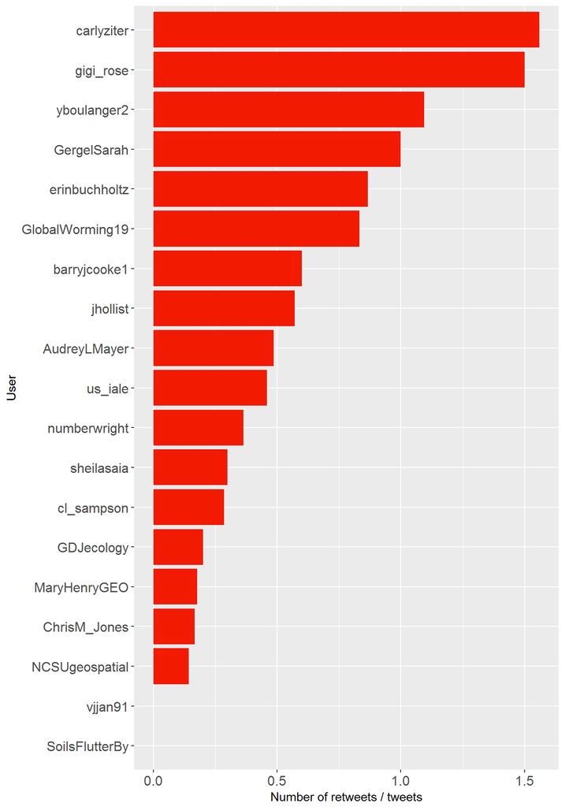

## Word cloud

The top 100 words among the original tweets.

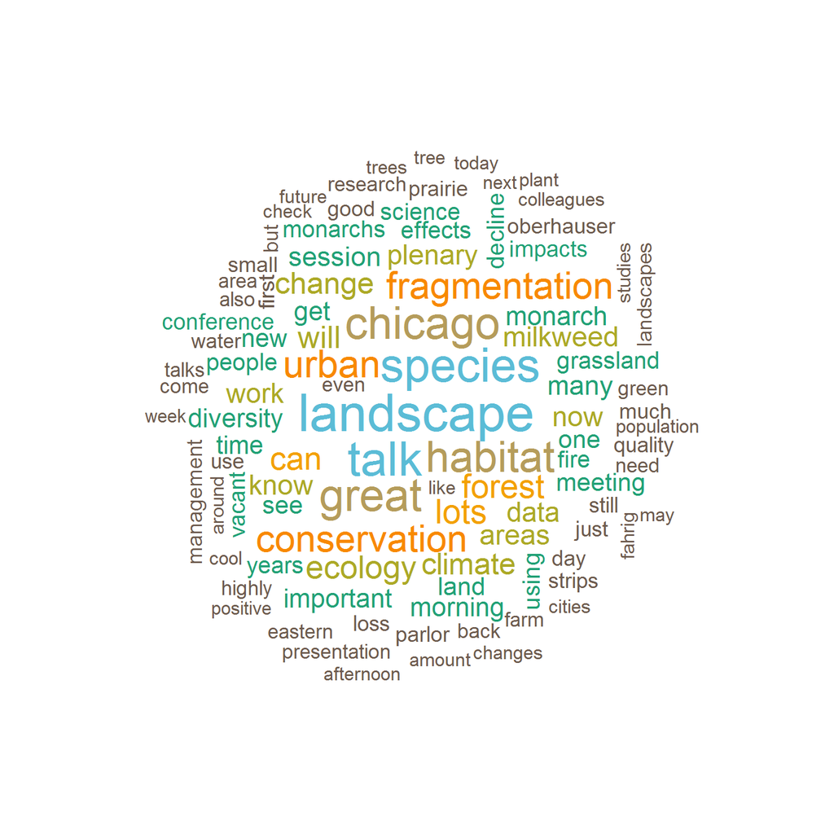

## Most commonly associated words

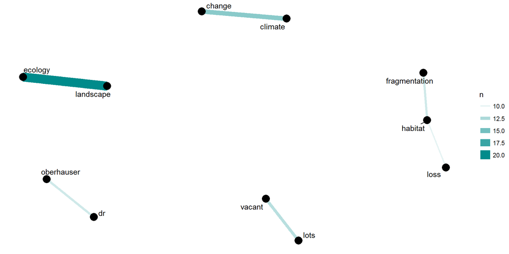

## Sentiment analysis

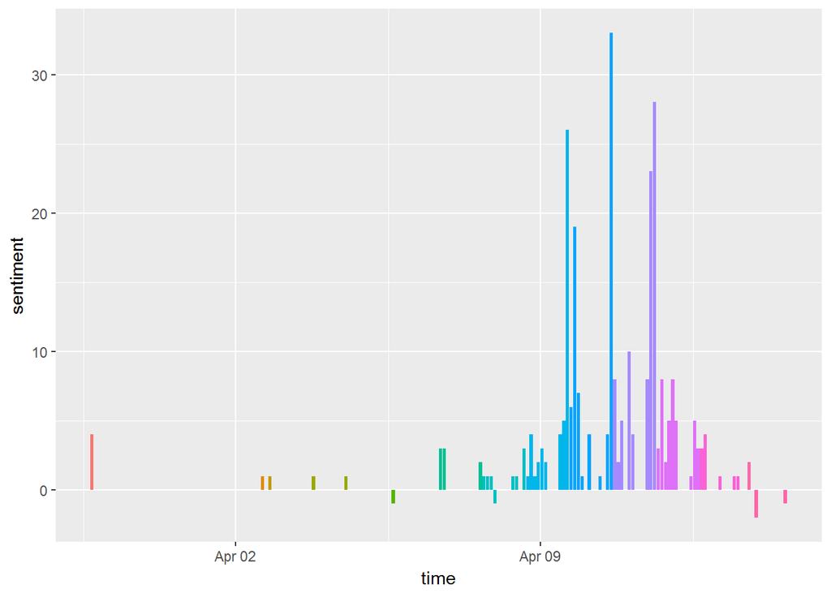